# Poisson inner-product latent-position recovery

## Source and scope

This report reads saved results and never calls MCMC. The source is **Python pilot from 2026-10-15, not an R refit**. The canonical result artifact is /Users/sheng/Documents/ChatGPT/freeway_accidents/results/gp_lpr/historical-python-20261015/study.rds.

The model is Poisson with an intercept, centered endpoint effects, and centered bounded latent positions. No GP is included. Historical imports preserve their original four chains and 2,000 stored draws per chain; they are not relabeled as R fits. A `quick` R run is an execution check only, not convergence evidence.

## Aligned position recovery

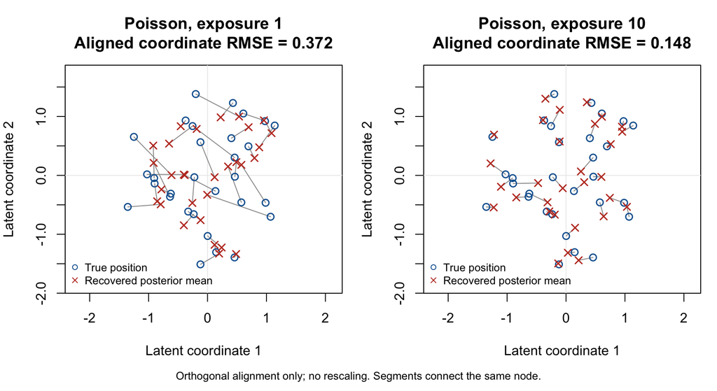

Circles are true centered positions and crosses are recovered posterior means. Each gray segment joins the same node. All posterior draws are first aligned to a fixed reference chosen without truth, then averaged. The resulting mean is aligned to truth for simulation evaluation by an orthogonal transformation allowing reflections. Neither stage rescales positions. Both panels use the same axes and aspect ratio. The plot shows point estimates, not credible regions.

| regime | position_rmse | interaction_rmse | interaction_correlation |
| --- | --- | --- | --- |
| Poisson, exposure 1 | 0.372 | 0.478 | 0.771 |
| Poisson, exposure 10 | 0.148 | 0.209 | 0.961 |

For these historical draws, the exposure-10 run has worst interaction Rhat 1.0121 (above 1.01), interval inclusion 0.906, and an intercept interval excluding truth. These limitations remain. Only one true configuration was simulated; point recovery does not establish interval calibration or sparse-road recovery. Historical imports lack raw endpoint and RNG checkpoints and cannot be continued.